# Survival Analysis - Lung Cancer

Noelia Caba Martin

2026-03-17

## Introduction

This analysis explores survival patterns in patients with advanced lung cancer using the `lung` dataset from the `survival` package in R.

The dataset contains clinical data from 228 patients, including survival time, censoring status, and several clinical variables.

The main objectives are:

- Estimate overall survival using Kaplan-Meier curves
- Compare survival between groups using the log-rank test
- Identify prognostic factors using Cox regression

## Setup

```r
library(survival)
library(survminer)
library(ggplot2)
```

## Data Exploration

```r
data(lung)
head(lung)
```

```
##   inst time status age sex ph.ecog ph.karno pat.karno meal.cal wt.loss
## 1    3  306      2  74   1       1       90       100     1175      NA
## 2    3  455      2  68   1       0       90        90     1225      15
## 3    3 1010      1  56   1       0       90        90       NA      15
## 4    5  210      2  57   1       1       90        60     1150      11
## 5    1  883      2  60   1       0      100        90       NA       0
## 6   12 1022      1  74   1       1       50        80      513       0
```

```r
dim(lung)
```

```
## [1] 228  10
```

```r
str(lung)
```

```
## 'data.frame':    228 obs. of  10 variables:
##  $ inst     : num  3 3 3 5 1 12 7 11 1 7 ...
##  $ time     : num  306 455 1010 210 883 ...
##  $ status   : num  2 2 1 2 2 1 2 2 2 2 ...
##  $ age      : num  74 68 56 57 60 74 68 71 53 61 ...
##  $ sex      : num  1 1 1 1 1 1 2 2 1 1 ...
##  $ ph.ecog  : num  1 0 0 1 0 1 2 2 1 2 ...
##  $ ph.karno : num  90 90 90 90 100 50 70 60 70 70 ...
##  $ pat.karno: num  100 90 90 60 90 80 60 80 80 70 ...
##  $ meal.cal : num  1175 1225 NA 1150 NA ...
##  $ wt.loss  : num  NA 15 15 11 0 0 10 1 16 34 ...
```

```r
summary(lung)
```

```
##       inst            time            status           age
##  Min.   : 1.00   Min.   :   5.0   Min.   :1.000   Min.   :39.00
##  1st Qu.: 3.00   1st Qu.: 166.8   1st Qu.:1.000   1st Qu.:56.00
##  Median :11.00   Median : 255.5   Median :2.000   Median :63.00
##  Mean   :11.09   Mean   : 305.2   Mean   :1.724   Mean   :62.45
##  3rd Qu.:16.00   3rd Qu.: 396.5   3rd Qu.:2.000   3rd Qu.:69.00
##  Max.   :33.00   Max.   :1022.0   Max.   :2.000   Max.   :82.00
##  NA's   :1
##       sex           ph.ecog          ph.karno        pat.karno
##  Min.   :1.000   Min.   :0.0000   Min.   : 50.00   Min.   : 30.00
##  1st Qu.:1.000   1st Qu.:0.0000   1st Qu.: 75.00   1st Qu.: 70.00
##  Median :1.000   Median :1.0000   Median : 80.00   Median : 80.00
##  Mean   :1.395   Mean   :0.9515   Mean   : 81.94   Mean   : 79.96
##  3rd Qu.:2.000   3rd Qu.:1.0000   3rd Qu.: 90.00   3rd Qu.: 90.00
##  Max.   :2.000   Max.   :3.0000   Max.   :100.00   Max.   :100.00
##                  NA's   :1        NA's   :1        NA's   :3
##     meal.cal         wt.loss
##  Min.   :  96.0   Min.   :-24.000
##  1st Qu.: 635.0   1st Qu.:  0.000
##  Median : 975.0   Median :  7.000
##  Mean   : 928.8   Mean   :  9.832
##  3rd Qu.:1150.0   3rd Qu.: 15.750
##  Max.   :2600.0   Max.   : 68.000
##  NA's   :47       NA's   :14
```

The dataset contains **228 patients** and **10 variables**. Key variables for survival analysis are `time` (survival time in days) and `status` (1 = censored, 2 = dead).

Notable missing data: `meal.cal` has 47 missing values (20.6%) and `wt.loss` has 14 missing values (6.1%).

## Kaplan-Meier Analysis

```r
# Create survival object
surv_object <- Surv(time = lung$time, event = lung$status == 2)

# Fit Kaplan-Meier model
km_fit <- survfit(surv_object ~ 1, data = lung)

# Summary at key timepoints
summary(km_fit, times = c(180, 365, 540, 720))
```

```
## Call: survfit(formula = surv_object ~ 1, data = lung)
##
##  time n.risk n.event survival std.err lower 95% CI upper 95% CI
##   180    160      63    0.722  0.0298       0.6655        0.783
##   365     65      58    0.409  0.0358       0.3447        0.486
##   540     33      22    0.255  0.0344       0.1962        0.333
##   720     14      15    0.125  0.0290       0.0789        0.197
```

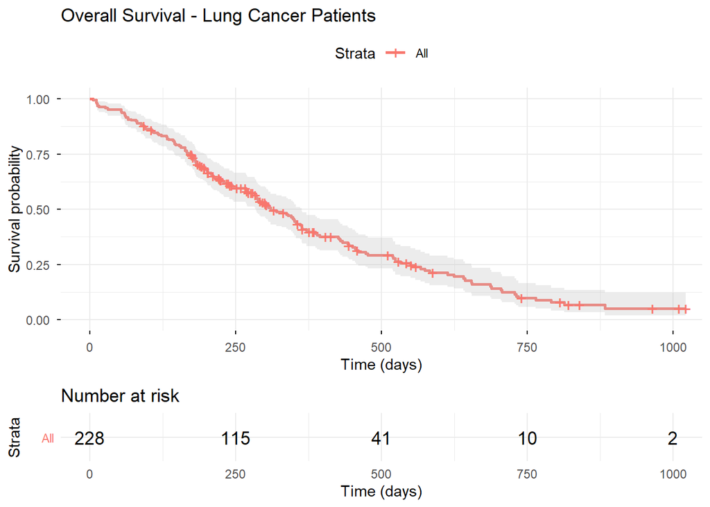

```r
ggsurvplot(
  km_fit,
  data = lung,
  risk.table = TRUE,
  pval = FALSE,
  conf.int = TRUE,
  xlab = "Time (days)",
  ylab = "Survival probability",
  title = "Overall Survival - Lung Cancer Patients",
  ggtheme = theme_minimal()
)
```

The Kaplan-Meier curve shows a steep decline in survival probability during the first year, with a median survival time of approximately 305 days.

At 6 months, 72.2% of patients were still alive (95% CI: 66.5% - 78.3%). At 1 year, survival dropped to 40.9% (95% CI: 34.5% - 48.6%). At 2 years, only 12.5% of patients remained alive (95% CI: 7.9% - 19.7%).

The wide confidence intervals at later timepoints reflect the small number of patients remaining at risk, which reduces the precision of the estimates.

## Survival by Sex

A key clinical question is whether survival differs between male and female patients with advanced lung cancer.

**Hypothesis:**

- **H₀ (null hypothesis):** There is no difference in survival between male and female patients
- **H₁ (alternative hypothesis):** There is a statistically significant difference in survival between male and female patients

The log-rank test will be used to compare the two survival curves, with a significance threshold of α = 0.05.

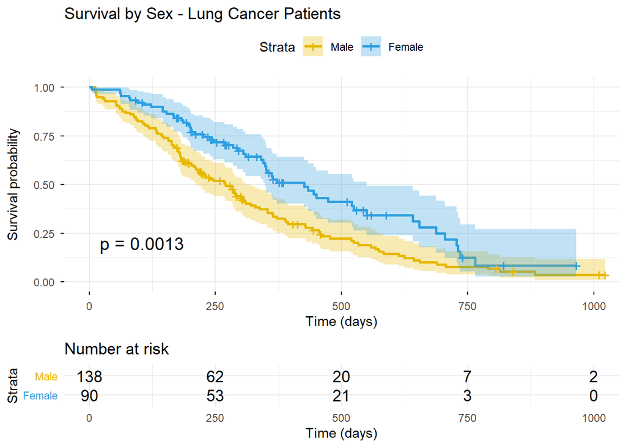

```r
# Fit Kaplan-Meier by sex
km_sex <- survfit(surv_object ~ sex, data = lung)

# Plot
ggsurvplot(
  km_sex,
  data = lung,
  risk.table = TRUE,
  pval = TRUE,
  conf.int = TRUE,
  xlab = "Time (days)",
  ylab = "Survival probability",
  title = "Survival by Sex - Lung Cancer Patients",
  legend.labs = c("Male", "Female"),
  palette = c("#E7B800", "#2E9FDF"),
  ggtheme = theme_minimal()
)
```

While the Kaplan-Meier analysis allows us to compare survival between groups, it can only evaluate one variable at a time. Cox proportional hazards regression allows us to assess the effect of multiple variables simultaneously, adjusting for potential confounders.

The key output of Cox regression is the **Hazard Ratio (HR)**:

- **HR = 1:** no effect on survival
- **HR > 1:** increased risk of death
- **HR < 1:** reduced risk of death (protective factor)

**Hypothesis:**

- **H₀:** None of the included variables (age, sex, ECOG status) are associated with survival
- **H₁:** At least one variable is significantly associated with survival

The following variables were selected based on clinical relevance and data completeness:

- **Age:** continuous variable, measured in years
- **Sex:** binary variable (1 = male, 2 = female)
- **ECOG performance status:** ordinal scale measuring patient functional status (0 = asymptomatic, 4 = bedridden)

```r
# Fit Cox model
cox_fit <- coxph(surv_object ~ age + sex + ph.ecog, data = lung)

# Summary
summary(cox_fit)
```

```
## Call:
## coxph(formula = surv_object ~ age + sex + ph.ecog, data = lung)
##
##   n= 227, number of events= 164
##    (1 observation deleted due to missingness)
##
##              coef exp(coef)  se(coef)      z Pr(>|z|)
## age      0.011067  1.011128  0.009267  1.194 0.232416
## sex     -0.552612  0.575445  0.167739 -3.294 0.000986 ***
## ph.ecog  0.463728  1.589991  0.113577  4.083 4.45e-05 ***
## ---
## Signif. codes:  0 '***' 0.001 '**' 0.01 '*' 0.05 '.' 0.1 ' ' 1
##
##         exp(coef) exp(-coef) lower .95 upper .95
## age        1.0111     0.9890    0.9929    1.0297
## sex        0.5754     1.7378    0.4142    0.7994
## ph.ecog    1.5900     0.6289    1.2727    1.9864
##
## Concordance= 0.637  (se = 0.025 )
## Likelihood ratio test= 30.5  on 3 df,   p=1e-06
## Wald test            = 29.93  on 3 df,   p=1e-06
## Score (logrank) test = 30.5  on 3 df,   p=1e-06
```

The Cox regression model was fitted on 227 patients (1 observation deleted due to missing data). A total of 164 events (deaths) were observed.

**Results:**

The model shows good overall fit, with all three global tests highly significant (p = 1×10⁻⁶), indicating that the included variables jointly predict survival.

- **Age** (HR = 1.011, 95% CI: 0.993 - 1.030, p = 0.232): Age was not a significant predictor of survival after adjusting for sex and ECOG status. Each additional year of age was associated with only a 1.1% increase in the hazard of death.
- **Sex** (HR = 0.575, 95% CI: 0.414 - 0.799, p = 0.001): Female sex was associated with a 42.5% reduction in the hazard of death compared to males, after adjusting for age and ECOG status. This is a statistically significant and clinically meaningful finding.
- **ECOG performance status** (HR = 1.590, 95% CI: 1.273 - 1.986, p < 0.001): Each one-unit increase in ECOG score was associated with a 59% increase in the hazard of death. This was the strongest prognostic factor in the model.

The model concordance of 0.637 indicates moderate discriminative ability, which is typical for clinical survival models.

**Conclusion:** After adjusting for confounders, sex and ECOG performance status are independent prognostic factors for survival in advanced lung cancer patients, while age did not reach statistical significance in this model.

The results of the Cox regression are visualized below using a **forest plot**, which is the standard representation in clinical publications.

Each variable is displayed with its Hazard Ratio (point estimate) and 95% confidence interval (horizontal line). The vertical dashed line at HR = 1 represents the reference value of no effect:

- Variables with the confidence interval entirely to the **left of 1** are protective (reduce the risk of death)
- Variables with the confidence interval entirely to the **right of 1** increase the risk of death
- Variables whose confidence interval **crosses 1** are not statistically significant.

```r
ggforest(
  cox_fit,
  data = lung,
  main = "Hazard Ratios - Cox Regression Model",
  cpositions = c(0.02, 0.22, 0.4),
  fontsize = 0.9,
  refLabel = "Reference",
  noDigits = 2
)
```

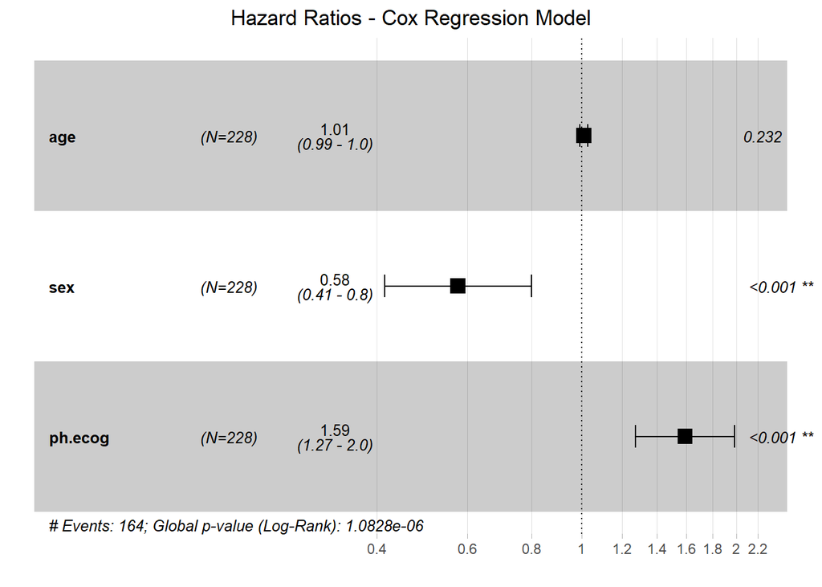

The forest plot confirms the results from the Cox regression table:

- **Age** is not a significant prognostic factor (HR = 1.01, p = 0.232), as its confidence interval crosses the line of no effect (HR = 1)
- **Sex** is a significant protective factor (HR = 0.58, p < 0.001), with the entire confidence interval to the left of HR = 1
- **ECOG performance status** is the strongest risk factor (HR = 1.59, p < 0.001), with the entire confidence interval to the right of HR = 1

## Verification of Cox Model Assumptions

The Cox proportional hazards model relies on a key assumption: the hazard ratios must remain **constant over time** (proportional hazards assumption). If this assumption is violated for any variable, the model results for that variable may not be reliable.

The proportional hazards assumption is tested using **Schoenfeld residuals**. For each variable, the test evaluates:

- **H₀:** The proportional hazards assumption holds (HR is constant over time)
- **H₁:** The proportional hazards assumption is violated (HR changes over time)

A p-value > 0.05 indicates that the assumption is met for that variable.

```r
# Test proportional hazards assumption
ph_test <- cox.zph(cox_fit)

# Print results
print(ph_test)
```

```
##         chisq df    p
## age     0.188  1 0.66
## sex     2.305  1 0.13
## ph.ecog 2.054  1 0.15
## GLOBAL  4.464  3 0.22
```

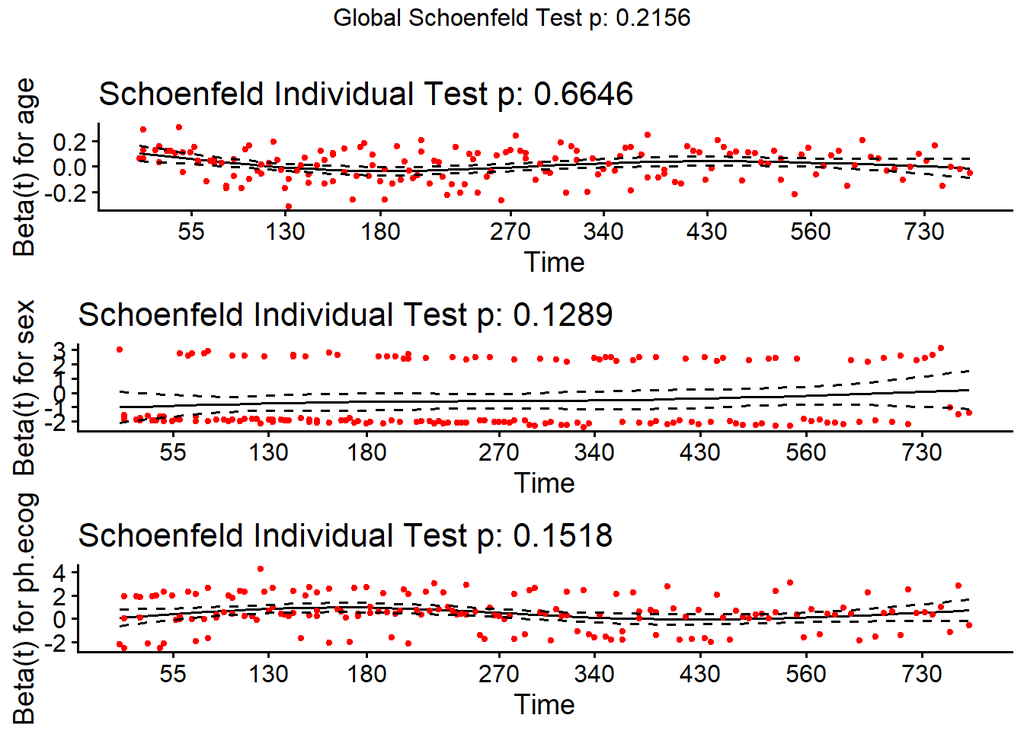

```r
# Plot Schoenfeld residuals
ggcoxzph(ph_test)
```

The Schoenfeld residuals test confirms that the proportional hazards assumption is met for all variables:

- **Age** (p = 0.665): assumption holds ✓
- **Sex** (p = 0.129): assumption holds ✓
- **ECOG status** (p = 0.152): assumption holds ✓
- **Global test** (p = 0.216): the model as a whole satisfies the proportional hazards assumption ✓

The graphical inspection of Schoenfeld residuals confirms these results, with all variables showing approximately horizontal smoothed lines over time, indicating stable hazard ratios throughout the follow-up period.

**Conclusion:** The proportional hazards assumption is not violated, validating the use of the Cox model for this dataset.

## Conclusions

This analysis demonstrates the application of standard survival analysis methods to real clinical data from patients with advanced lung cancer.

**Key findings:**

1. The median overall survival was approximately 305 days, with only 12.5% of patients surviving beyond 2 years, reflecting the poor prognosis associated with advanced lung cancer.
2. Female patients showed significantly better survival than male patients (log-rank p = 0.0013), a finding that remained significant after adjusting for confounders in the Cox model (HR = 0.58, p < 0.001).
3. ECOG performance status was the strongest independent prognostic factor (HR = 1.59, p < 0.001), confirming that functional status at diagnosis is a critical determinant of survival outcomes.
4. Age was not a significant predictor of survival in this model (HR = 1.01, p = 0.232), suggesting that functional status and sex are more important prognostic factors than age alone in this patient population.

**Limitations:**

- The dataset contains missing values in several variables, particularly `meal.cal` (20.6% missing), which were excluded from the analysis
- The study population is limited to North American patients from a single clinical trial, which may limit generalizability
- Additional variables such as tumor histology, stage, and treatment information were not available in this dataset

**Future directions:**

- Include additional clinical and molecular variables to improve model performance
- Validate the model in an independent dataset
- Explore machine learning approaches for survival prediction